# Day7_TeamLopez

Bart Driessen & Peter Hooiveld

14 Jan 2015

Setting global settings

```r
library(raster)
library(rgdal)
library(pls)
```

Step 1: Getting all the right data.

```r
filelist <- list.files("data/bands/", full.names = T)
for (i in 1:length(filelist)){
  load(filelist[i])
}
gewata <- brick(GewataB1,GewataB2,GewataB3,GewataB4,GewataB5,GewataB7)
```

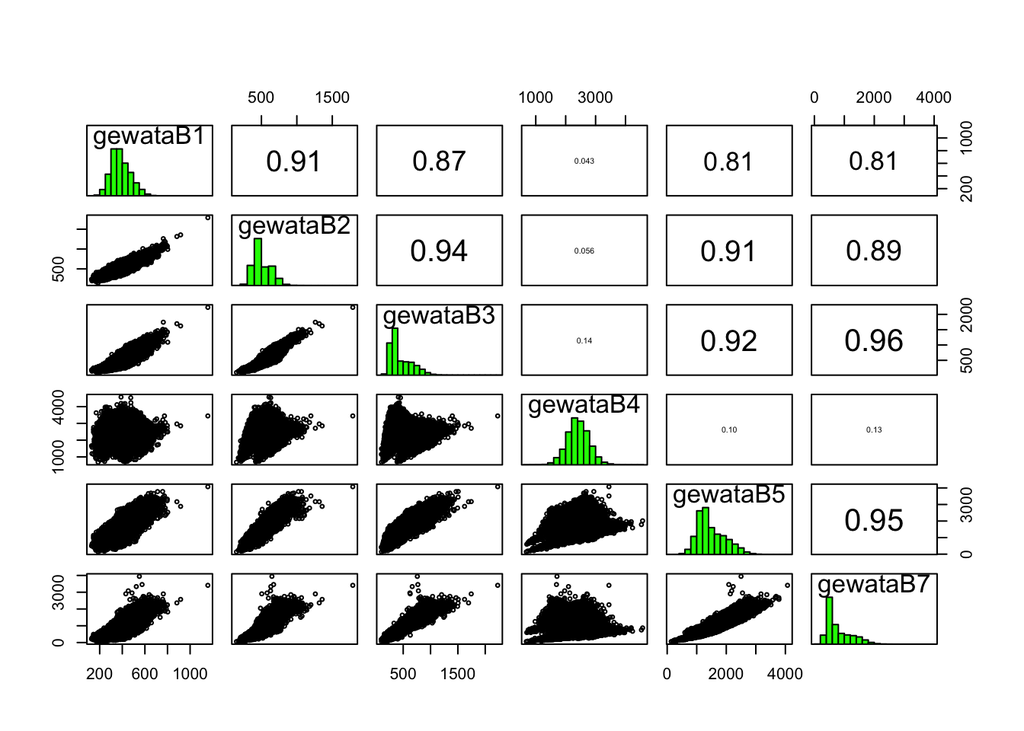

B4 has a very low correlation, so this one is omitted from the covs.

```r
vcfGewata[vcfGewata > 100] <- NA
ndvi <- overlay(GewataB4, GewataB3, fun=function(x,y){(x-y)/(x+y)})

covs <- addLayer(gewata,vcfGewata,ndvi)
covs <- dropLayer(covs,"gewataB4")
names(covs) <- c("band1","band2","band3","band5","band7","vcf","ndvi")
```

Step 3: Create a liniear model of the model object. First, load the training polygons.

```r
load("data/trainingPoly.rda")
```

We can convert to integer by using the as.numeric() function, which takes the factor levels.

```r
trainingPoly@data$Code <- as.numeric(trainingPoly@data$Class)
```

Assign ‘Code’ values to raster cells (where they overlap)

```r
classes <- rasterize(trainingPoly, ndvi, field='Code')
```

We can quickly visualize the training polygons:

[figure not shown]

```r
covmasked <- mask(covs, classes)
```

Combine this new brick with the classes layer to make our input training dataset.

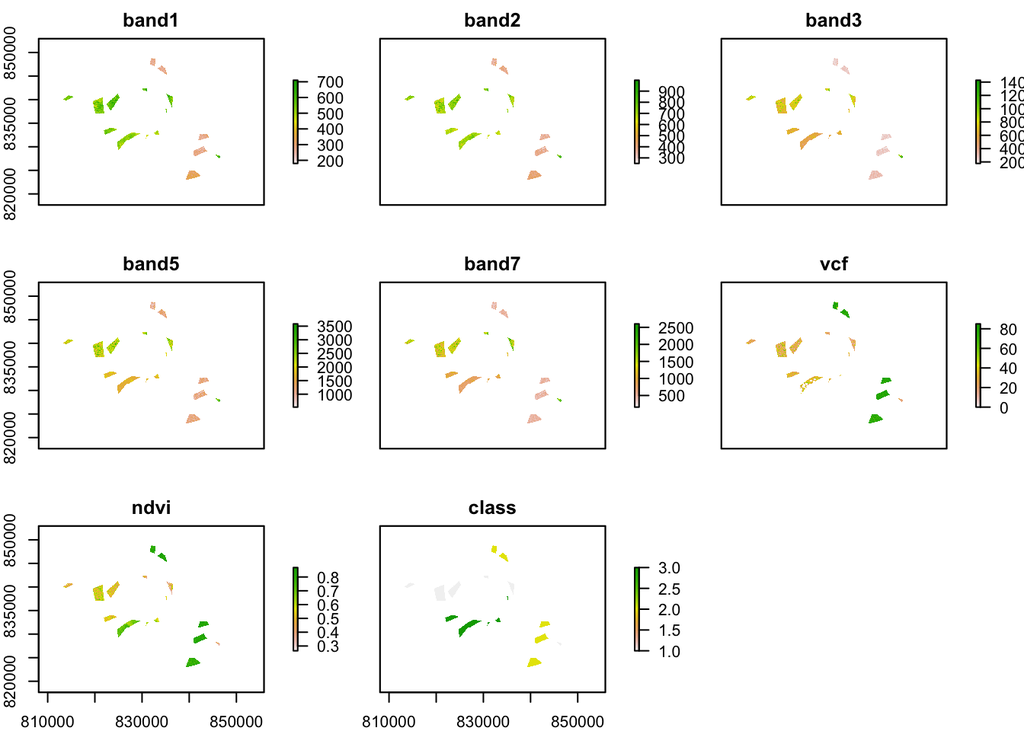

```r
names(classes) <- "class"
trainingbrick <- addLayer(covmasked, classes)
plot(trainingbrick)
```

Extract all values into a matrix.

```r
valuetable <- getValues(trainingbrick)
valuetable <- na.omit(valuetable)
valuetable <- as.data.frame(valuetable)
```

Building a linear model.

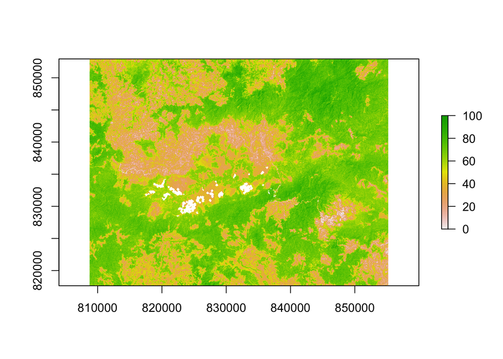

```r
modelLM <- lm(vcf~band1+band2+band3+band5+band7+ndvi,data=valuetable)
predLM <- predict(covs, model=modelLM, na.rm=TRUE)
predLM@data@values[predLM@data@values < 0] <- 0
predLM@data@values[predLM@data@values > 100] <- 100
```

```r
summary(modelLM)
```

```
##
## Call:
## lm(formula = vcf ~ band1 + band2 + band3 + band5 + band7 + ndvi,
##     data = valuetable)
##
## Residuals:
##     Min      1Q  Median      3Q     Max
## -42.035  -4.119   0.037   4.058  45.031
##
## Coefficients:
##               Estimate Std. Error t value Pr(>|t|)
## (Intercept)  3.336e+01  1.082e+00   30.84   <2e-16 ***
## band1        3.599e-02  1.281e-03   28.10   <2e-16 ***
## band2       -1.385e-01  1.188e-03 -116.61   <2e-16 ***
## band3        4.908e-02  1.173e-03   41.85   <2e-16 ***
## band5       -1.452e-02  4.089e-04  -35.51   <2e-16 ***
## band7        1.030e-02  5.097e-04   20.21   <2e-16 ***
## ndvi         1.024e+02  1.258e+00   81.41   <2e-16 ***
## ---
## Signif. codes:  0 '***' 0.001 '**' 0.01 '*' 0.05 '.' 0.1 ' ' 1
##
## Residual standard error: 7.12 on 36213 degrees of freedom
## Multiple R-squared:  0.9177, Adjusted R-squared:  0.9177
## F-statistic: 6.729e+04 on 6 and 36213 DF,  p-value: < 2.2e-16
```

We can see that all bands are important. This is caused by the fact that we threw out band 4 at the beginning because we already figured that it would be useless due to the outcome of pairs().

Step 4: Plot the predicted tree cover raster and original VCF raster.

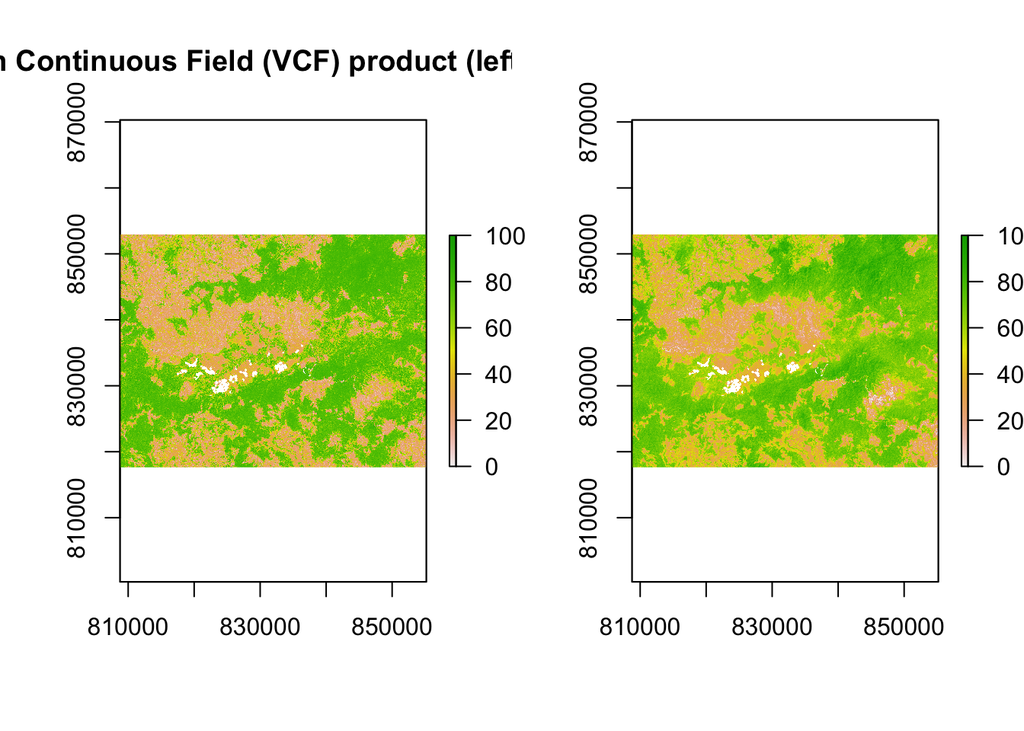

Step 5: Calculate RSME between predicted and VCF raster.

```r
rmse = sqrt(mean((predLM@data@values - covs$vcf@data@values)^2, na.rm = TRUE))
sprintf('The RMSE is %f',rmse)
```

```
## [1] "The RMSE is 9.472334"
```

Step 6: Calculate RSME for different training areas.

```r
rmsepzone <- as.data.frame(zonal((predLM - covs$vcf)^2,classes))
names(rmsepzone)[2] <- 'rmse'
for(i in 1:3){
  rmsepzone$rmse[i] <- sqrt(rmsepzone$rmse[i])
}
sprintf('The RMSE per zone is: zone 1: %f, zone 2: %f, zone 3: %f',rmsepzone$rmse[1], rmsepzone$rmse[2], rmsepzone$rmse[3])
```

```
## [1] "The RMSE per zone is: zone 1: 8.017489, zone 2: 4.690525, zone 3: 8.726209"
```